# Лабораторная работа 9. Интерпретация результатов иерархического кластерного анализа с помощью деревьев классификации

Natalia Korskova

2016-03-30

### Вариант 14. Растения Армориканской возвышенности

Считываем данные из файла:

```r
plants.01 <- read.table("plants.dat", header = TRUE, sep = ";")
```

Посмотрим на краткие описательные статистики:

```r
summary(plants.01)
```

```
##    plant.name      pdias            longindex         durflow
##  Aceca  :  1   Min.   :   0.010   Min.   :0.0000   Min.   : 1.000
##  Aceps  :  1   1st Qu.:   0.460   1st Qu.:0.0000   1st Qu.: 2.000
##  Agrca  :  1   Median :   1.575   Median :0.4444   Median : 3.000
##  Agrst  :  1   Mean   :  70.764   Mean   :0.4060   Mean   : 3.184
##  Ajure  :  1   3rd Qu.:   8.505   3rd Qu.:0.7230   3rd Qu.: 4.000
##  Allpe  :  1   Max.   :1684.300   Max.   :1.0000   Max.   :12.000
##  (Other):130   NA's   :36         NA's   :25
##      height         begflow          mycor           vegaer
##  Min.   :1.000   Min.   :1.000   Min.   :0.000   Min.   :0.0000
##  1st Qu.:2.000   1st Qu.:4.000   1st Qu.:1.000   1st Qu.:0.0000
##  Median :4.000   Median :5.000   Median :2.000   Median :0.0000
##  Mean   :4.118   Mean   :5.169   Mean   :1.598   Mean   :0.2164
##  3rd Qu.:5.000   3rd Qu.:6.000   3rd Qu.:2.000   3rd Qu.:0.0000
##  Max.   :8.000   Max.   :9.000   Max.   :2.000   Max.   :2.0000
##                                  NA's   :39      NA's   :2
##     vegsout          autopoll         insects           wind
##  Min.   :0.0000   Min.   :0.0000   Min.   :0.000   Min.   :0.0000
##  1st Qu.:0.0000   1st Qu.:0.0000   1st Qu.:0.000   1st Qu.:0.0000
##  Median :0.0000   Median :0.0000   Median :3.000   Median :0.0000
##  Mean   :0.4254   Mean   :0.8897   Mean   :2.022   Mean   :0.9853
##  3rd Qu.:1.0000   3rd Qu.:2.0000   3rd Qu.:3.000   3rd Qu.:3.0000
##  Max.   :2.0000   Max.   :3.0000   Max.   :4.000   Max.   :4.0000
##  NA's   :2
##       lign             piq             ros             semiros
##  Min.   :0.0000   Min.   :0.000   Min.   :0.00000   Min.   :0.0000
##  1st Qu.:0.0000   1st Qu.:0.000   1st Qu.:0.00000   1st Qu.:0.0000
##  Median :0.0000   Median :0.000   Median :0.00000   Median :0.0000
##  Mean   :0.3162   Mean   :0.125   Mean   :0.09091   Mean   :0.2652
##  3rd Qu.:1.0000   3rd Qu.:0.000   3rd Qu.:0.00000   3rd Qu.:1.0000
##  Max.   :1.0000   Max.   :1.000   Max.   :1.00000   Max.   :1.0000
##                                   NA's   :4         NA's   :4
##      leafy            suman            winan            monocarp
##  Min.   :0.0000   Min.   :0.0000   Min.   :0.00000   Min.   :0.00000
##  1st Qu.:0.0000   1st Qu.:0.0000   1st Qu.:0.00000   1st Qu.:0.00000
##  Median :1.0000   Median :0.0000   Median :0.00000   Median :0.00000
##  Mean   :0.6439   Mean   :0.1397   Mean   :0.08824   Mean   :0.06618
##  3rd Qu.:1.0000   3rd Qu.:0.0000   3rd Qu.:0.00000   3rd Qu.:0.00000
##  Max.   :1.0000   Max.   :1.0000   Max.   :1.00000   Max.   :1.00000
##  NA's   :4
```

[output cut: 9 more lines]

```
##  Min.   :0.0000   Min.   :0.0000   Min.   :0.0000   Min.   :0.0000
##  1st Qu.:0.0000   1st Qu.:0.0000   1st Qu.:0.0000   1st Qu.:0.0000
##  Median :0.0000   Median :0.0000   Median :0.0000   Median :0.0000
##  Mean   :0.4091   Mean   :0.1515   Mean   :0.0916   Mean   :0.2901
##  3rd Qu.:1.0000   3rd Qu.:0.0000   3rd Qu.:0.0000   3rd Qu.:1.0000
##  Max.   :1.0000   Max.   :1.0000   Max.   :1.0000   Max.   :1.0000
##  NA's   :4        NA's   :4        NA's   :5        NA's   :5
##      epizoo           aquat            windgl            unsp
##  Min.   :0.0000   Min.   :0.0000   Min.   :0.0000   Min.   :0.0000
##  1st Qu.:0.0000   1st Qu.:0.0000   1st Qu.:0.0000   1st Qu.:0.0000
##  Median :0.0000   Median :0.0000   Median :0.0000   Median :0.0000
##  Mean   :0.1679   Mean   :0.0229   Mean   :0.1756   Mean   :0.2901
##  3rd Qu.:0.0000   3rd Qu.:0.0000   3rd Qu.:0.0000   3rd Qu.:1.0000
##  Max.   :1.0000   Max.   :1.0000   Max.   :1.0000   Max.   :1.0000
##  NA's   :5        NA's   :5        NA's   :5        NA's   :5
```

Отбросим столбцы с большим количеством пропущенных значений (25 и более):

```r
plants.02 <- subset(plants.01, select = -c(2, 3, 7))
```

В оставшей выборке помимо названий растений остальные величины являются факторами, поэтому будем рассматривать нормализацию методом feature-scaling с максимумом 1:

```r
normalize <- function(x) {
    return ((x - min(na.omit(x))) / (max(na.omit(x)) - min(na.omit(x))))
  }
plants.02.fs <- as.data.frame(lapply(plants.02[, 2:29], normalize))
```

```r
for(i in 1:ncol(plants.02.fs)){
  plants.02.fs[is.na(plants.02.fs[,i]), i] <- mean(plants.02.fs[,i], na.rm = TRUE)
}
```

Иерархический кластерный анализ:

Составляем матрицу попарных расстояний, проводим кластерный анализ:

```r
clust.fs <- hclust(dist(plants.02.fs), "ward.D")
```

По результатам кластерного анализа дендрограмму делили на 5 кластеров:

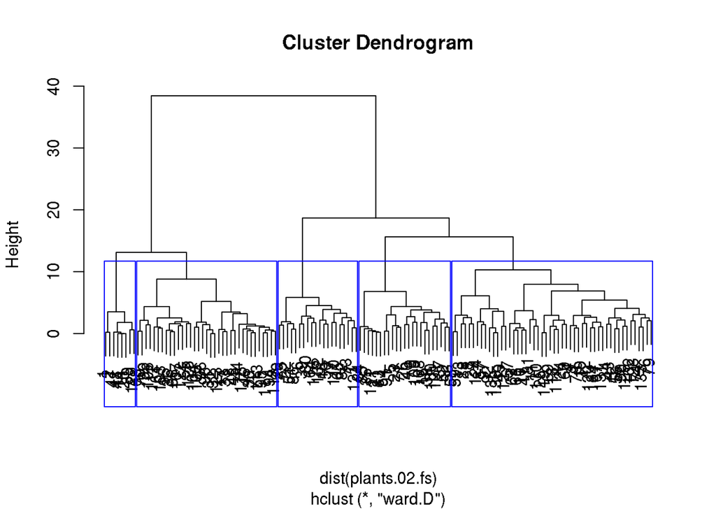

```r
plot(clust.fs)
rect.hclust(clust.fs, k = 5, border = "blue")
```

```r
groups.fs.5 <- cutree(clust.fs, k=5)
```

Второй вариант – на 3 кластера:

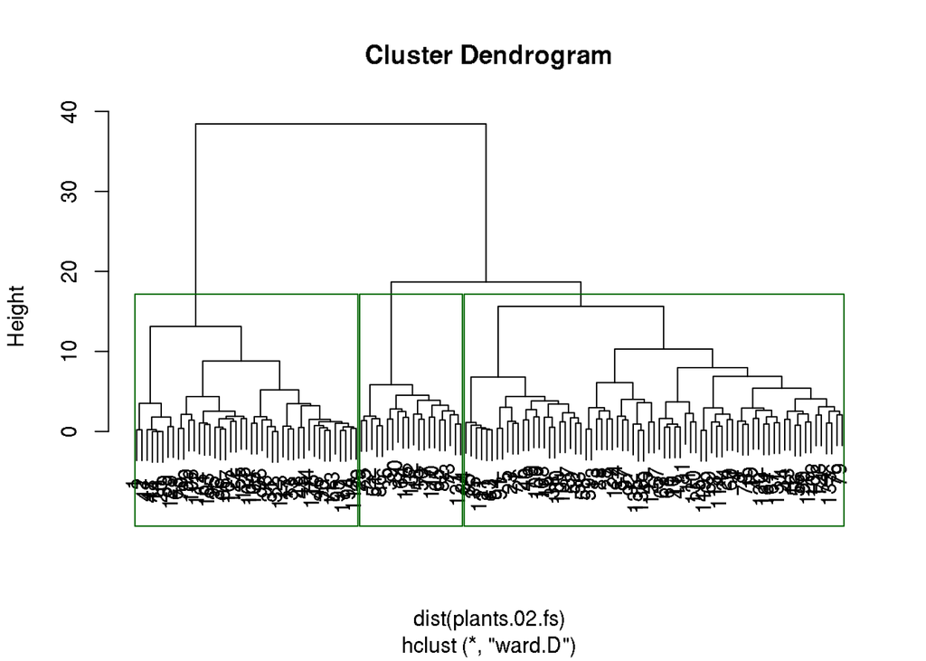

```r
plot(clust.fs)
rect.hclust(clust.fs, k = 3, border = "darkgreen")
```

```r
groups.fs.3 <- cutree(clust.fs, k=3)
```

Рассмотрим интерпретацию результатов обоих вариантов кластеризации при помощи решающих деревьев. Сначала 5 классов. Добавим к ненормализованным данным столбец, в котором будет записан номер кластера:

```r
plants.03 <- plants.02[2:29]
cl <- rep(1, nrow(plants.03))
plants.03$cl <- cl
plants.03$cl[groups.fs.5 == 2] <- 2
plants.03$cl[groups.fs.5 == 3] <- 3
plants.03$cl[groups.fs.5 == 4] <- 4
plants.03$cl[groups.fs.5 == 5] <- 5
```

Для оценки качества работы решающих деревьев разобьём выборку на тестовое и обучающее множество:

```r
set.seed(3141)
test_num <- sample(1:nrow(plants.03), 45, replace = FALSE)
train_1 <- plants.03[-test_num, ]
test_1 <- plants.03[test_num, ]
```

Решающие деревья на обучающем множестве:

```r
library(rpart)
res_1 <- rpart(cl ~., data = train_1, method="class", control = rpart.control(minsplit=10, minbucket=5, maxdepth=6))
res_1
```

```
## n= 91
##
## node), split, n, loss, yval, (yprob)
##       * denotes terminal node
##
##  1) root 91 60 2 (0.077 0.34 0.16 0.13 0.29)
##    2) endozoo< 0.5 63 34 2 (0.11 0.46 0.24 0.19 0)
##      4) suman< 0.5 52 23 2 (0.13 0.56 0.29 0.019 0)
##        8) semiros< 0.5 35  8 2 (0.2 0.77 0 0.029 0)
##         16) height>=6 8  1 1 (0.88 0.12 0 0 0) *
##         17) height< 6 27  1 2 (0 0.96 0 0.037 0) *
##        9) semiros>=0.5 17  2 3 (0 0.12 0.88 0 0) *
##      5) suman>=0.5 11  0 4 (0 0 0 1 0) *
##    3) endozoo>=0.5 28  2 5 (0 0.071 0 0 0.93) *
```

Графическое изображение дерева:

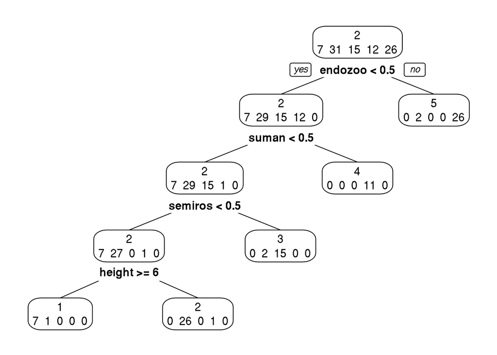

```r
library(rpart.plot)
rpart.plot(res_1, type = 2, extra = 1)
```

Ошибок не очень много, 5 листьев при 5 классах – обрезать нечего. Работа на тестовом множестве:

```r
pred_1 <- predict(res_1, test_1, type="class")
table(test_1$cl, pred_1)
```

```
##    pred_1
##      1  2  3  4  5
##   1  1  0  0  0  0
##   2  0 15  3  0  1
##   3  0  0  8  0  0
##   4  0  0  0  8  0
##   5  0  0  0  0  9
```

Количество ошибок на тестовом множестве сравнимо с ошибками на обучающем – работа решающего дерева считается удовлетворительной. Интерпретация результата:

К 5-му кластеру относятся растения, у которых переменная endozoo равна 1 – способ распространения семян через пищеварительный тракт животного. В остальных кластерах растения, у которых эта переменная равна 0. В 4-м кластере растения с переменной suman, равной 1 – цветение летом (также endozoo = 0). В остальных кластерах растения без летнего цветения. Далее в 3-м кластере растения со значением переменной semiros, равной 1 – полурозоцветные (также endozoo = 0, suman = 0). Во втором кластере не очень высокие растения с endozoo, suman, semiros, равными 0. В первом кластере самые высокие растения – деревья (endozoo, suman, semiros равны 0).

Разбиение на 3 кластера:

```r
plants.04 <- plants.02[2:29]
cl <- rep(1, nrow(plants.04))
plants.04$cl <- cl
plants.04$cl[groups.fs.3 == 2] <- 2
plants.04$cl[groups.fs.3 == 3] <- 3
```

Тестовое и обучающее множество:

```r
train_2 <- plants.04[-test_num, ]
test_2 <- plants.04[test_num, ]
res_2 <- rpart(cl ~., data = train_2, method="class", control = rpart.control(minsplit=10, minbucket=5, maxdepth=6))
res_2
```

```
## n= 91
##
## node), split, n, loss, yval, (yprob)
##       * denotes terminal node
##
## 1) root 91 45 2 (0.36263736 0.50549451 0.13186813)
##   2) lign>=0.5 32  1 1 (0.96875000 0.03125000 0.00000000) *
##   3) lign< 0.5 59 14 2 (0.03389831 0.76271186 0.20338983)
##     6) suman< 0.5 48  3 2 (0.04166667 0.93750000 0.02083333) *
##     7) suman>=0.5 11  0 3 (0.00000000 0.00000000 1.00000000) *
```

Графическое изображение:

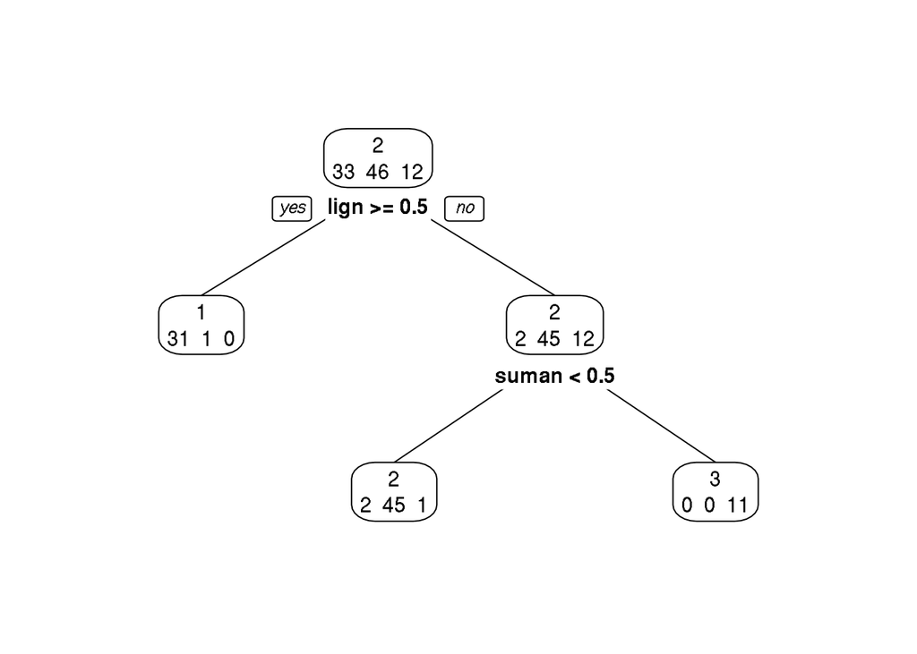

```r
rpart.plot(res_2, type = 2, extra = 1)
```

```r
pred_2 <- predict(res_2, test_2, type="class")
table(test_2$cl, pred_2)
```

```
##    pred_2
##      1  2  3
##   1  8  2  0
##   2  3 24  0
##   3  0  0  8
```

Тоже не очень много ошибок. Интерпретация результата:

Растения из первого класса имеют значение переменной lign, равное 1 – растения, которые являются деревьями. Остальные классы не являются деревьями. Растения второго класса не имеют летнего цветения, растения третьего класса с летним цветением.

Если не разбивать на тестовое и обучающее множество для трёх кластеров, дерево получается сложнее и его нужно обрезать. Построим дерево для трёх кластеров на всей выборке:

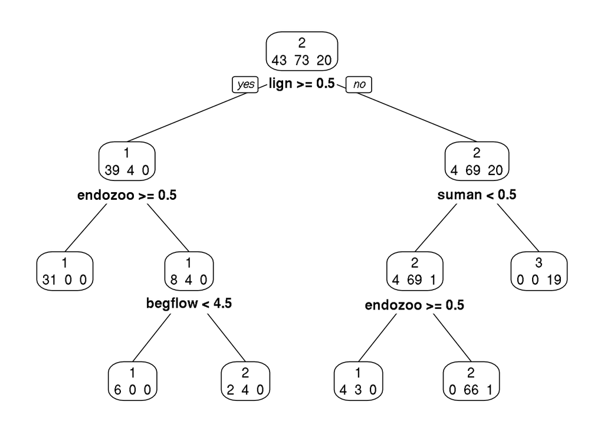

```r
res_3 <- rpart(cl ~., data = plants.04, method="class", control = rpart.control(minsplit=10, minbucket=5, maxdepth=6))
rpart.plot(res_3, type = 2, extra = 1)
```

Листьев сильно больше, чем классов – неудобно интерпретировать. Увеличим минимальное число элементов в листе:

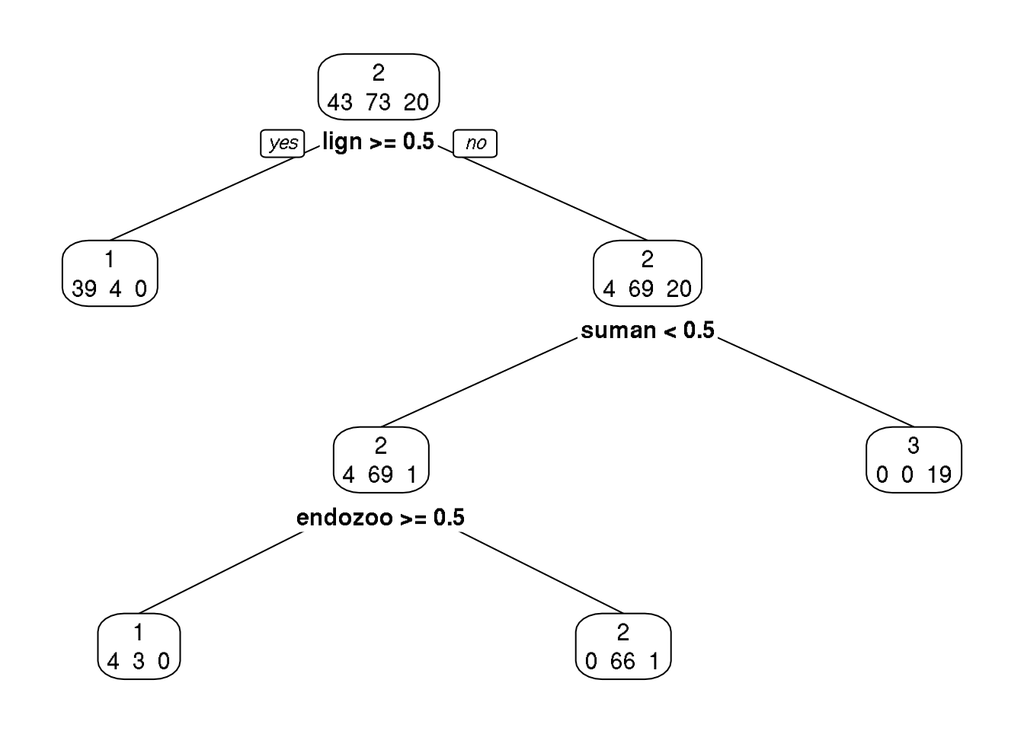

```r
res_4 <- rpart(cl ~., data = plants.04, method="class", control = rpart.control(minsplit=15, minbucket=5, maxdepth=6))
rpart.plot(res_4, type = 2, extra = 1)
```

Получилось дерево небольшой глубины и не очень много ошибок, всего 4 листа. Разбиение по endozoo является незначительным, уберём его, уменьшив глубину дерева:

```r
res_5 <- rpart(cl ~., data = plants.04, method="class", control = rpart.control(minsplit=15, minbucket=5, maxdepth=2))
res_5
```

```
## n= 136
##
## node), split, n, loss, yval, (yprob)
##       * denotes terminal node
##
## 1) root 136 63 2 (0.31617647 0.53676471 0.14705882)
##   2) lign>=0.5 43  4 1 (0.90697674 0.09302326 0.00000000) *
##   3) lign< 0.5 93 24 2 (0.04301075 0.74193548 0.21505376)
##     6) suman< 0.5 74  5 2 (0.05405405 0.93243243 0.01351351) *
##     7) suman>=0.5 19  0 3 (0.00000000 0.00000000 1.00000000) *
```

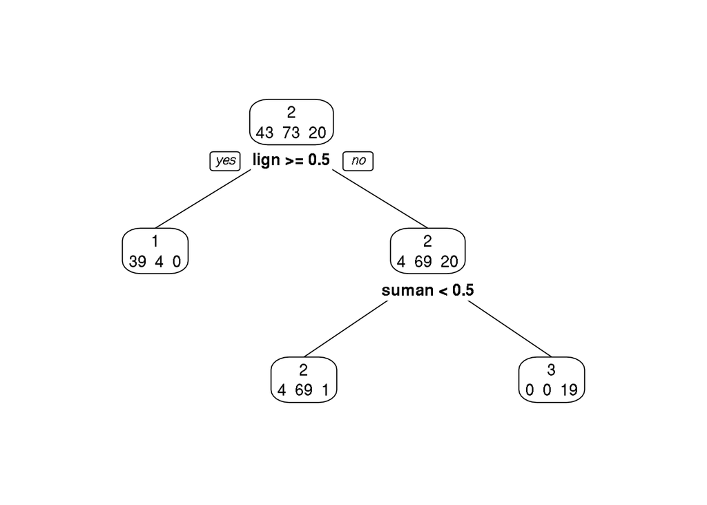

```r
rpart.plot(res_5, type = 2, extra = 1)
```

Три листа и три класса, небольшое число ошибок – результат удовлетворительный. Получилось такое же дерево, как при разбиении на обучающее и тестовое множество.